# Linking R to data from ArcGIS Online and Open Data

### Bill DeVoe, MaineDMR GIS Coordinator, William.DeVoe@maine.gov

## Pulling data from an item’s Open Data page

Using the example of lobster zones - under the Download button is a link for a ShapeFile. Under the API link is a link to a GeoJSON. I find GeoJSONs more useful. They avoid some of the issues with ShapeFiles, particularly the 8 character limit on field names, which can be a problem if an agency publishes data with field names like `lobsters_number_caught` and `lobsters_number_released`, which when converted to a ShapeFile will become `LOBSTE_1` and `LOBSTE_2`.

Grabbing the link to the GeoJSON, this can be converted to an SP object using the `geojsonio` package.

```r
library(geojsonio)

# URL to query for GeoJSON
url <- "https://opendata.arcgis.com/datasets/55a305a17acd46f58675d955e4fcaa83_0.geojson"
# Read GeoJSON as spatial dataframe
zones <- geojsonio::geojson_read(url, what="sp")
# Columns have full names
names(zones)
```

```
[1] "OBJECTID"         "ZONEID"           "created_user"     "created_date"     "last_edited_user"
[6] "last_edited_date"
```

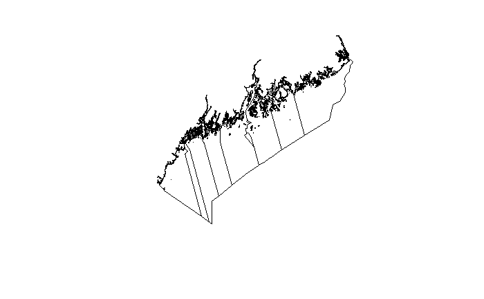

```r
# Take a look
plot(zones)
```

## Scraping data from an AGOL or ArcServer Service

Many agencies publish data to AGOL or host data from an ArcServer deployment, but do not share the data with an Open Data portal. This data can be acquired from the REST endpoint of the service, which is under URL on an AGOL item’s page.

### For simple services

For services with less features than the query limit, a link for a GeoJSON can be generated with the query engine and used with the code chunk above.

To generate the URL:

1. On the item’s page, click the layer within the item.

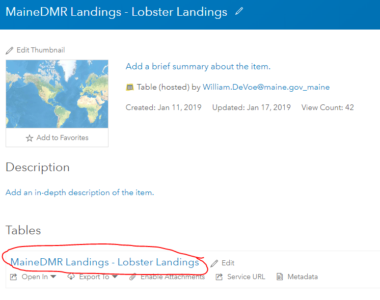

2. The service endpoint page for the item will appear. Make note of the `Max Record Count`.

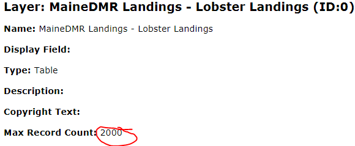

3. Scroll to the bottom and select `Query`.

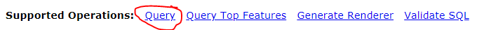

4. On the query page, for the `Where` field enter `1=1`.
5. Set `Return Count Only` to `True` and click `Query (GET)`. The number of records in the dataset will be returned. If this number is higher than the number observed for the service’s `Max Record Count`, you will need to use the method in the next section.

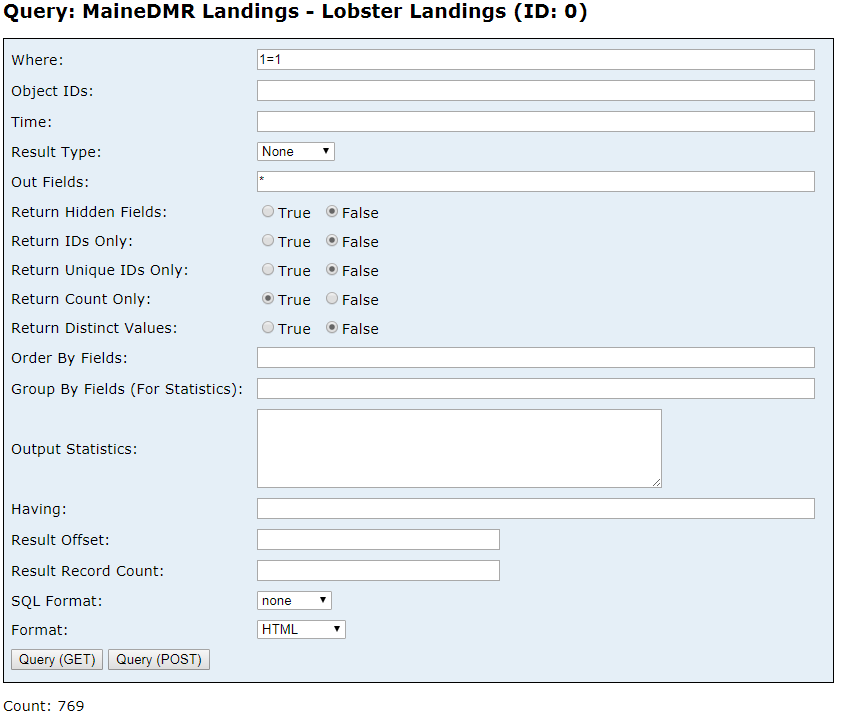

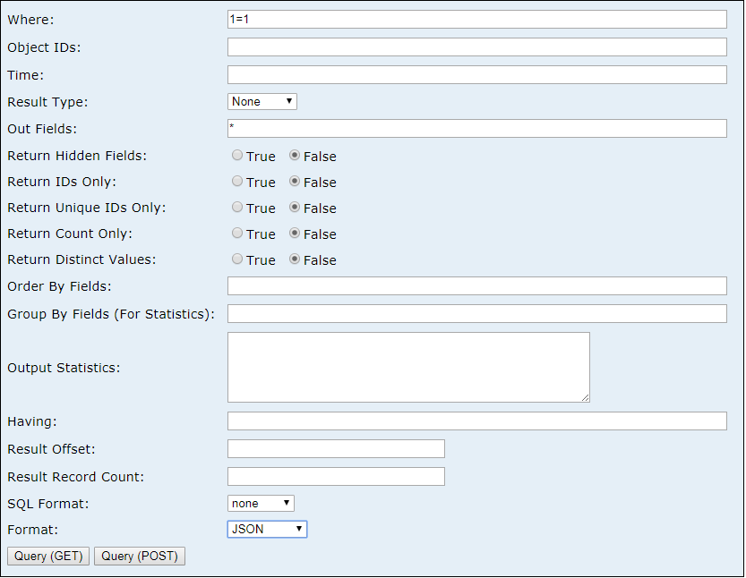

7. The resulting page should look similar to this - what you are looking at is a parsed JSON of the query submitted.

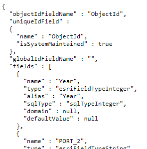

8. Copy the URL of this page from the browser navigation bar. For this example, the URL is:

`https://services1.arcgis.com/RbMX0mRVOFNTdLzd/arcgis/rest/services/MaineDMR_Lobster_Landings/FeatureServer/0/query?where=1%3D1&objectIds=&time=&resultType=none&outFields=*&returnHiddenFields=false&returnIdsOnly=false&returnUniqueIdsOnly=false&returnCountOnly=false&returnDistinctValues=false&orderByFields=&groupByFieldsForStatistics=&outStatistics=&having=&resultOffset=&resultRecordCount=&sqlFormat=none&f=pjson&token=9wqzi8hNagsvO4QgwXFb_Du_i2_9rtkJD2flRW_hk93IySjDwimfjeG9VeyarRhvDfIVeqKGPOgMqw6l81bfpdMkdSpajg6HRuuPcBPagbKVh6bA3kWkJnqmR09-DoWs5qyH8IOadWlinyRj5dMFUkMjUHQM2jJy-VW44-umvUTfTDG5dxZIL3DjglHfcyBTlcWO5xiKhDM8wt8hIDhetHTS4ZNplveO7VaEUfE_Ovk1CLr9RqFPzfv9IYaRL5YRtIuTak4Mpk8YOYL20DV72g..`

9. Remove the token on the end of the URL so that the end of the URL is `&f=pjson`. The final query URL in this example would be this:

`https://services1.arcgis.com/RbMX0mRVOFNTdLzd/arcgis/rest/services/MaineDMR_Lobster_Landings/FeatureServer/0/query?where=1%3D1&objectIds=&time=&resultType=none&outFields=*&returnHiddenFields=false&returnIdsOnly=false&returnUniqueIdsOnly=false&returnCountOnly=false&returnDistinctValues=false&orderByFields=&groupByFieldsForStatistics=&outStatistics=&having=&resultOffset=&resultRecordCount=&sqlFormat=none&f=pjson`

10. Use this URL in the code chunk above to pull in the GeoJSON.

### For services with more features than the query limit

The package `esri2sf` available at https://github.com/yonghah/esri2sf will iterate over the query limit to convert an ArcGIS Online service to an SF object. Full documentation is included on the package’s GitHub page.